# Théorie des Probabilités

Marchand Jean-Louis

2025-02-13

# 1. Pas de panique

## 1.1 Dans les grandes lignes

- on va tout reprendre de 0.
- premiere étape : le dénombrement, mais pas trop longtemps non-plus.
- but final : arriver jusqu’aux résultats classiques de la théorie des probabilités et leur lien à la loi normale (ou de Gauss) pour ouvrir sur le cours de statistiques de l’an prochain
- historiquement : gagner de l’argent aux jeux de hasard
- maintenant : partout ! (ou presque)
  - économie
  - sondage
  - médecine
  - météorologie
  - biologie
  - physique
  - chimie
  - sport
  - etc.

# 2. Généralités

## 2.1 Quelle utilisation ?

- **modéliser** une **expérience** réelle
  - lancers de dé, tirage de cartes
  - phénomène plus ou moins **aléatoire**
- pour l’expérience considérée, **issue incertaine**
- objectifs restreints dans une situation trop complexe
  - cerner au mieux l’ensemble des possibles : l’**univers**
  - quantifier la propension d’une situation plausible, un **évènement** à se réaliser plus qu’une autre : la **probabilité de l’évènement** (généralisation du *principe de proportion*)

## 2.2 Un peu d’histoire (mais pas trop non plus)

- contrairement à l’analyse (variations, dérivation, équations différentielles, intégrales …) le cadre mathématique de la théorie des probabilités est plutôt récent
- les premières briques formulées au 17e sur des situations de jeu d’argent
- le cadre commun à toutes les situations aléatoires apparu début 20e (axiomatique de Kolmogorov), les éléments clairement cernés :
  - l’**univers**, noté souvent \(\Omega\) regroupant toutes les **éventualités** de l’expérience considérée
  - la **tribu**, représentant l’ensemble des **évènements** considérés associés à l’expérience
  - la **probabilité**, une **fonction** qui à un évènement associe une valeur réelle entre 0 et 1
  - la **variable aléatoire**, une **fonction** qui à une éventualité associe un élément (**réel** dans le cadre de cours)
- exemples :
  - *la probabilité de gagner au loto* : il faut tenir compte du fait que l’ensemble de toutes les grilles possibles, un évènement correspond à une collection de grilles, la probabilité est ici la proportion de grilles constituant l’évènement sur le nombre total de grilles
  - *la probabilité qu’il pleuve demain* : plus compliqué de maîtriser les éléments, on ramène l’étude générale à l’étude d’une partie du phénomène, une ou plusieurs mesures (température, pression, humidité, etc.)

### 2.2.1 Rappels sur la manipulation d’ensembles

- un **sous-ensemble** (ou **partie**) \(A\) d’un ensemble \(B\) est un ensemble dont tous les éléments **appartiennent** à \(B\)
  - notation : \(A\subset B\) et \(x\in A\)
- le **cardinal** compte le nombre d’éléments
  - notation : \(\#A\)
- un ensemble est **fini** s’il comporte un nombre fini d’éléments, sinon il est **infini**
  - exemples : \(\{1,2\}\) fini, \([1,2]\) infini
- un ensemble est **dénombrable** si on peut numéroter ses éléments sinon il est **indénombrable**
  - exemples : \(\mathbb Q\) dénombrable, \(\mathbb R\) indénombrable
- la **réunion** de deux ensembles est l’ensemble des éléments appartenant à **au moins** un des deux ensembles
  - notation : \(A\cup B\)
- l’**intersection** de deux ensembles est l’ensemble des éléments **communs** aux deux ensembles
  - notation : \(A\cap B\)
- le **complémentaire** d’un ensemble \(A\) dans un ensemble \(B\) contenant \(A\) est le sous-ensemble de \(B\) formé des éléments qui n’appartiennent pas à \(A\)
  - notation \(\bar A\) (attention aux ambiguïtés !)

## 2.3 Cadre mathématique : Univers

- toutes ces notions liées à une volonté d’étendre le traitement naturel des situations simples (ex : lancer de dé)
- la notion de proportion omniprésente
- recherche de cohérence et de compatibilité des différents objets entre eux

### 2.3.1 Définition

> l’**univers** noté \(\Omega\) est un **ensemble** de tous les **éléments** \(\omega\) représentant chacun une **éventualité** de l’expérience considérée
- ex : lancer de dé, \(\Omega = \{1,2,3,4,5,6\}= \{\omega \in\mathbb N\colon 1\leq\omega\leq 6\}\)
- **Remarque importante** : cet ensemble pas toujours explicite notamment dans des situations complexes. Par ex. quel \(\Omega\) choisir en météorologie ?…

## 2.4 Cadre mathématique : Evénement

### 2.4.1 Idées importantes à retenir

> - un **évènement** : ensemble d’éventualités
> - la **tribu** : ensemble de tous les événements d’une expérience donnée
- compatibilité avec opérations : union, intersection, complémentaire
- quand \(\Omega\) dénombrable, souvent \(\mathcal T=\mathcal P(\Omega)\)
- quand \(\Omega\) infini indénombrable, impossible de choisir \(\mathcal T=\mathcal P(\Omega)\) d’où la définition

## 2.5 Cadre mathématique : Probabilité

- au risque d’insister lourdement : **généralisation du principe de proportion**, les règles de calculs sont des prolongements dans une certaine mesure des règles existantes sur les proportions
- compatibilité nécessaire avec les opérations sur les évènements

### 2.5.1 Définition

> une probabilité sur \(\Omega\) muni de la tribu \(\mathcal T\) est une fonction \(\mathbb P\) de \(\mathcal T\) dans \([0;1]\), telle que
> - \(\mathbb P(\Omega)=1\) (l’univers est certain)
> - si \(A_1,A_2,A_3,\dots\) suite d’éléments de \(\mathcal T\), deux à deux disjoints \((i\neq j\Rightarrow A_i \cap A_j=\emptyset)\), alors : $$\mathbb P( A_1 \cup A_2 \cup A_3 \cup \dots) = \mathbb P(A_1)+\mathbb P(A_2)+\mathbb P(A_3)+\dots$$ (probabilité d’une réunion d’évènements disjoints/incompatibles égal à la somme des probabilités respectives des évènements)
- vision possible et **conseillée** : la masse !

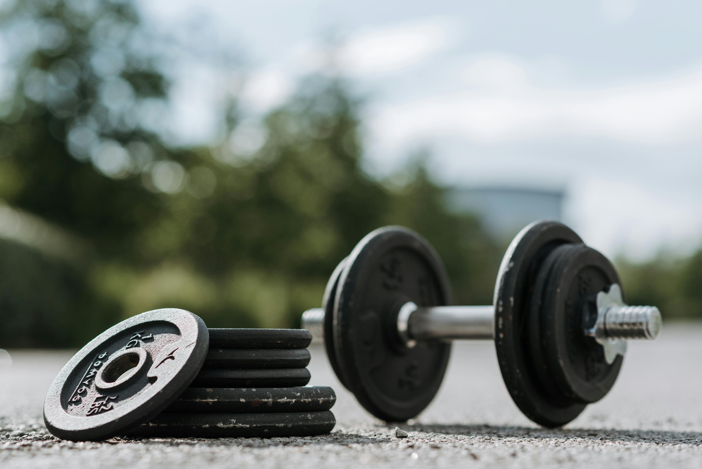

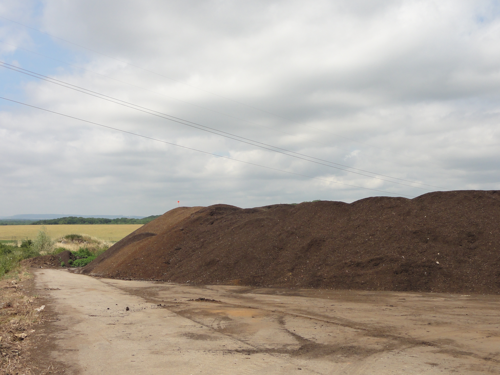

## 2.6 Cadre mathématique : Probabilité

### 2.6.1 Propriété

> soit \(\mathbb P\) une probabilité sur \((\Omega, \mathcal T)\), et \(A,B\in\mathcal T\)
> - \(\mathbb P(\emptyset) =0\)
> - \(\mathbb P(\bar A) = 1-\mathbb P(A)\)
> - \(\mathbb P(A\cup B) = \mathbb P(A) + \mathbb P(B) - \mathbb P(A\cap B)\)
> - si \(A\subset B,\quad \mathbb P(A)\leq \mathbb P(B)\)
- exercice : prouvez-le !
- à travers la définition, on retrouve tout ce qui fonctionne bien avec des proportions et/ou des masses

# 3. Probabilités sur univers fini

## 3.1 La base de compréhension des probabilités

- cadre le plus simple (ou moins compliqué ?) à partir duquel tous les enjeux sont cernés/ illustration des définitions précédentes
- premier cas : situation d’équiprobabilité
  - ex : dé équilibré
  - contre-ex : dé déséquilibré
- en situation d’**équiprobabilité**, savoir compter suffit ! on retrouve exactement les **proportions**
- **dans beaucoup d’autres cas cela n’a pas de sens de se limiter au comptage !!!!**

## 3.2 Cas équiprobable

- c’est la **seule** situation où la probabilité d’un évènement est une **proportion de cas**, il faut faire l’hypothèse d’**équiprobabilité** des issues de l’expérience considérée, la probabilité correspond alors dans ce cas à la proportion de cas correspondants : $$\mathbb P(A) =\frac{\textrm{Nombres d'issues dans }A}{\textrm{Nombre total d'issues de l'expérience}}$$
- en pratique, on commence par **modéliser** l’expérience
  - description des issues \(\omega\in\Omega\)
  - comptage du nombre total d’issues de l’expérience, noté \(\# \Omega\)
  - comptage du nombre total d’issues dans \(A\), noté \(\# A\)
  - calcul de la probabilité $$\mathbb P(A)=\frac{\# A}{\#\Omega}$$

### 3.2.1 Exemples

1. quelle est la probabilité de n’avoir aucun 6 sur 3 lancers successifs d’un même dé ?
2. quelle est la probabilité de n’avoir aucun 6 sur le lancer de trois dés ?
3. quelle est la probabilité de n’avoir qu’un seul 6 sur 3 lancers de dé ?
4. quelle est la probabilité d’avoir un carré (4 cartes de même valeur) au poker ?
5. calculer la probabilité d’obtenir exactement 5 fois un 6 sur 10 lancers

## 3.3 Et sinon ?

- en l’absence de cette hypothèse, il peut se passer beaucoup de choses mais pas n’importe quoi non plus !

### 3.3.1 Propriété

> si \(\Omega=\{\omega_1,\dots,\omega_n\}\) est un univers fini. Pour définir une probabilité sur l’univers \(\Omega\), il faut et il suffit de définir une liste de nombres positifs \((p_1,\dots,p_n)\) telle que
> - \(p_1+p_2+\dots+p_n=1\) (le total vaut 1)
> - \(p_k=\mathbb P(\{\omega_k\})\) (les probabilités de chaque issue sont connues)
- exemple : un dé truqué
- ce résultat reste valide si \(\Omega\) est **infini dénombrable**, par exemple lorsque l’on s’intéresse au premier 6 obtenu sur un dé

# 4. Retour au cadre général

## 4.1 Probabilités conditionnelles

- exemple : lecture des chiffres de la Covid franceinfo

### 4.1.1 Définition

> soient \(A\) et \(B\) deux événements tels que \(\mathbb P(B)\neq 0\), alors on définit la **probabilité conditionnelle de \(A\) sachant \(B\)** > est la quantité notée \(\mathbb P(A|B)\) définie par $$\mathbb P(A|B)=\frac{\mathbb P(A\cap B)}{\mathbb P(B)}$$

### 4.1.2 Propriété

> la probabilité conditionnelle \(\mathbb P(.|B)\) est une probabilité en tant que fonction et donc satisfait toutes les propriétés inhérentes
- cela signifie que toutes les règles restent vraies quand on travaille avec une probabilité conditionnelle
  - la probabilité conditionnelle de l’univers est 1, l’ensemble vide est 0
  - la probabilité conditionnelle d’une réunion disjointe est la somme des probabilités conditionnelles respectives
  - la probabilité conditionnelle du complémentaire d’un évènement donné est égale à un moins la probabilité conditionnelle de cet évènement
  - la probabilité conditionnelle d’un premier évènement inclus dans un second est plus petite que celle du second

## 4.2 Partition

[figure not shown]

### 4.2.1 Définition

> une famille d’événements non-vides \((A_1,\dots,A_n)\) forme une **partition** de \(\Omega\) si
> 1. \(\bigcup_{k=1}^n A_k = \Omega\)
> 2. \(A_i \cap A_j = \emptyset,\quad \forall i\neq j\)
- exemple : si \(A\neq \emptyset, \Omega\) alors \((A,\bar A)\) est une partition de \(\Omega\)
- une partition est un **découpage** de l’ensemble, où tout élément de \(\Omega\) appartient à un seul des \(A_k\) (un puzzle quoi !)
- en particulier $$\sum_{k=1}^n \mathbb P(A_k)=1$$

## 4.3 Formules centrales

### 4.3.1 Probabilités totales

> soit \((A_1,\dots,A_n)\) une partition de \(\Omega\) alors pour tout événement \(B\) $$\mathbb P(B) = \sum_{k=1}^n \mathbb P(B|A_k)\mathbb P(A_k)$$

### 4.3.2 Formule de Bayes

> sous les mêmes hypothèses $$\mathbb P(A_{k_0}|B) = \frac{\mathbb P(B|A_{k_0})\mathbb P(A_{k_0})}{\sum_{k=1}^n \mathbb P(B|A_k)\mathbb P(A_k)}$$

## 4.4 Jeu de Monty Hall

- trois portes se présentent au joueur, derrière l’une d’entre elles se cache le gros lot, en l’occurrence une voiture
- le joueur choisit dans un premier temps l’une des trois portes
- le présentateur ouvre une autre porte perdante, laissant le choix au joueur de changer son choix
- quelle est la meilleure stratégie à suivre ?

## 4.5 Indépendance

### 4.5.1 Définition

> deux événements \(A\) et \(B\) sont **indépendants** si $$\mathbb P(A|B)=\mathbb P(A)$$

### 4.5.2 Propriété

> soient \(A\) et \(B\) deux événements tels que \(\mathbb P(A),\mathbb P(B)\neq 0\), alors les assertions suivantes son équivalentes
> 1. \(\mathbb P(A|B)=\mathbb P(A)\)
> 2. \(\mathbb P(A|\bar B)=\mathbb P(A)\)
> 3. \(\mathbb P(A\cap B)=\mathbb P(A)\mathbb P(B)\)
> 4. \(\mathbb P(B|A)=\mathbb P(B)\)

# 5. Variables aléatoires

## 5.1 Pourquoi ?

- jusqu’ici, l’issue \(\omega\) a été supposée entièrement observée, pour pouvoir notamment comparer plusieurs informations liées à une même issue aussi complexe qu’elle soit, surtout lorsque l’on modélise des phénomènes réels

### 5.1.1 Définition

> une **variable aléatoire réelle** est une fonction qui à toute issue \(\omega \in\Omega\) associe un réel, cette fonction étant *compatible* avec la probabilité, au sens que pour tout intervalle \(I\) de réels, la quantité $$\mathbb P(X\in I)=\mathbb P(\{\omega\in\Omega \colon X(\omega)\in I\})$$ est toujours définie.
- en d’autres termes, on peut voir une variable aléatoire réelle comme une *mesure* effectuée sur l’issue d’une expérience
- quand le phénomène considéré est complexe, on cherche à multiplier les mesures, et étudier le lien entre elles

## 5.2 Variables aléatoires

- le cadre des probabilités permet de mettre en lien les différentes mesures sur une même issue

### 5.2.1 Définition

> un **couple de variables aléatoires réelles** est une fonction qui à toute issue \(\omega \in\Omega\) associe un couple de réels, cette fonction étant *compatible* avec la probabilité, au sens que pour tous intervalles \(I\) et \(J\) de réels, la quantité $$\mathbb P(X\in I,\, Y\in J)=\mathbb P(\{\omega\in\Omega \colon X(\omega)\in I \,\&\, Y(\omega)\in J\})$$ est toujours définie.
- on comprend alors que l’on peut étendre le principe à n’importe quelle taille de famille (même infinie) de variables aléatoires
- le but étant toujours de s’assurer une chose : considérer la possibilité que chacune des variables ne sorte pas d’une gamme de valeurs constitue un événement

## 5.3 Loi

### 5.3.1 Définition

> - la **loi d’une variable aléatoire réelle** est la donnée de la famille $$\left(\mathbb P(X\in I)\colon I \textrm{ intervalle réel }\right)$$
> - la **loi d’un couple de variables aléatoires réelles** est la donnée de la famille $$\left(\mathbb P(X\in I,\,Y\in J)\colon I,J \textrm{ intervalles réels }\right)$$
- les lois fournissent la **distribution** des valeurs possibles
- cette définition générale se simplifie dans deux familles de cas que nous allons étudier
  - les variables discrètes
  - les variables continues
- la différence se fait sur l’ensemble des valeurs possibles $$X(\Omega)= \{X(\omega) \colon \omega\in \Omega\}$$

## 5.4 Variables indépendantes

### 5.4.1 Définition

> deux variables réelles \(X\) et \(Y\) sont indépendantes si la loi du couple vérifie pour tous intervalles \(I\) et \(J\) $$\mathbb P(X\in I, Y\in J)=\mathbb P(X\in I)\mathbb P(Y\in J)$$
- cela revient à dire que tout évènement portant sur \(X\) est indépendant de tout évènement portant sur \(Y\)
- exemple : tirage avec ou sans remise
- généralisation raisonnable pour \(n\) variables aléatoires réelles, même une infinité

## 5.5 Variables aléatoires discrètes

- cas où \(X(\Omega)\) est dénombrable, on peut lister alors ses éléments $$X(\Omega)=\{x_k\colon k\in K\}$$ où \(K\subset \mathbb N\)

### 5.5.1 Propriété

> - la **loi d’une variable aléatoire discrète** sur \(X(\Omega)=\{x_k\colon k\in K\}\) est entièrement décrite par la suite \(\left( \mathbb P(X=x_k)\right)_{k\in K}\)
> - soit \(K\subset \mathbb N\), toute famille \(\left(p_k\right)_{k\in K}\) de réels compris entre 0 et 1, de somme totale égale à 1 permet de définir la loi d’une variable aléatoire discrète
- cette propriété permet la création simple de lois, notamment celles qui vont nous intéresser qui sont censées modéliser des situations type

## 5.6 Lois discrètes usuelles

- loi de Bernoulli de paramètre \(p\in ]0,1[\) : \(\qquad\mathcal B(p)\)
  - modèle du *Victoire* ou *Défaite*, où \(p\) probabilité de *Victoire*
- loi uniforme de paramètre \(\{1,\dots,n\}\): \(\qquad \mathcal U(\{1,\dots,n\})\)
  - tirage d’un nombre **entier** compris entre 1 et \(n\)
- loi binomiale de paramètres \(n\in \mathbb N^*,p\in ]0,1[\) : \(\qquad\mathcal B(n,p)\)
  - modèle du nombre de *Victoire* obtenus sur \(n\) épreuves successives indépendantes de \(Bernoulli\) de paramètre \(p\)
- loi de Poisson de paramètre \(\lambda>0\) : \(\qquad\mathcal P(\lambda)\)
  - modèle limite du nombre de réussites sur un très grand nombre d’épreuves de Bernoulli de paramètre \(p\) très petit (évènement rare)
- loi géométrique de paramètre \(p\in ]0,1[\) : \(\qquad\mathcal G(p)\)
  - modèle de la survenue de la première *Victoire* sur des épreuves successives indépendantes de Bernoulli de paramètres \(p\)
- loi hypergéométrique de paramètres \(N, N_1, n\) : \(\qquad\mathcal H(N,N_1,n)\)
  - modèle de tirage de \(n\) individus dans un mélange de deux populations de tailles respectives \(N_1\) et \(N-N_1\)

## 5.7 Loi de Bernoulli de paramètre \(p\)

[interactive chart not shown]

## 5.8 Loi binomiale pour \(n=10\) et \(p\)

[interactive chart not shown]

## 5.9 Loi binomiale pour \(n=100\) et \(p\)

[interactive chart not shown]

## 5.10 Loi de Poisson de paramètre \(\lambda\)

[interactive chart not shown]

## 5.11 Loi géométrique de paramètre \(p\)

[interactive chart not shown]

## 5.12 Loi hypergéométrique

[interactive chart not shown]

## 5.13 Propriétés remarquables

- la loi **de Poisson** permet de modéliser le nombre de réussites dans une succession d’un très grand nombre d’épreuves indépendantes de Bernoulli de même paramètre \(p\) où \(p\) est très petit (évènement rare)

### 5.13.1 Propriété : approximation de la loi binomiale par la loi de Poisson

> soit \((p_n)_{n\in\mathbb N}\) une suite de réels compris entre 0 et 1 telle que la suite \((np_n)_{n\in\mathbb N}\) soit convergente vers une constante non-nulle $$\lim_{n\to\infty}np_n=\lambda>0,$$ alors $$\lim_{n\to\infty}\binom nk p_n^k(1-p_n)^{n-k}=\frac{\lambda^k}{k!}e^{-\lambda}$$

## 5.14 Propriétés remarquables

- la famille des lois de Poisson présente une forme de stabilité

### 5.14.1 Propriété : somme de lois de Poisson

> si \(X\) et \(Y\) sont deux variables **indépendantes** de loi de Poisson de paramètres respectifs \(\lambda\) et \(\mu\) alors \(Z= X+Y\) suit une loi de Poisson de paramètre \(\lambda + \mu\)
- la famille des lois binomiales présente une forme de stabilité mais il faut bien vérifier que le deuxième paramètre est le même

### 5.14.2 Propriété : somme de lois binomiales

> si \(X\) et \(Y\) sont deux variables **indépendantes** de loi binomiales de paramètres respectifs \((n,p)\) et \((m,p)\) alors \(Z= X+Y\) suit une loi binomiales de paramètres \((n+m,p)\)

## 5.15 Espérance et variance

- la probabilité \(\mathbb P(\Omega)=1\) peut être vue comme la masse totale à répartir sur l’ensemble \(X(\Omega)\) des valeurs possibles, les indicateurs usuels :
  - le **centre de masse** localise le point d’équilibre
  - l’**inertie** renseigne sur la conservation de mouvement, ceci repose sur la répartition de la masse dans le système considéré

### 5.15.1 Définition

> l’**espérance** d’une variable aléatoire discrète \(X\) est la quantité notée \(\mathbb E[X]\) définie par la moyenne pondérée des valeurs de \(X(\Omega)\) $$\mathbb E[X] = \sum_k x_k \mathbb P(X=x_k)$$

## 5.16 Propriétés de l’espérance

- les propriétés restent vraies pour n’importe quelle variable aléatoire réelle

### 5.16.1 Propriété

> - l’espérance est linéaire $$\mathbb E[X+\lambda Y]= \mathbb E[X]+\lambda \mathbb E[Y]$$
> - l’espérance d’une variable aléatoire positive est positive
> - une variable **positive** dont l’espérance est nulle est nulle
> - si \(\forall \omega\in\Omega, \quad X(\omega)\leq Y(\omega)\) alors \(\mathbb E[X]\leq \mathbb E[Y]\)
> - **Théorème de transfert**, si \(Y=\varphi(X)\) alors $$\mathbb E[Y]=\mathbb E[\varphi(X)]=\sum_k \varphi(x_k)\mathbb P(X=x_k)$$
- ce dernier résultat permet de calculer l’espérance d’une variable à l’aide de la loi d’une autre, souvent parce que cela simplifie le calcul^

## 5.17 Définition

> - la **variance** est la quantité \(\mathbb V[X]\) définie comme la moyenne pondérée des carrés de l’écart à l’espérance $$\mathbb V[X] = \mathbb E[(X-\mathbb E[X])^2]= \sum_k (x_k-\mathbb E[X])^2 \mathbb P(X=x_k)$$
> - la **covariance** de deux variables réelles \(X\) et \(Y\) est la quantité \(\textrm{Cov}(X,Y)\) définie par $$\begin{array}{ll}\textrm{Cov}(X,Y)&=\mathbb E[(X-\mathbb E[X])(Y-\mathbb E[Y])]\\& = \displaystyle\sum_{j,k} (x_j-\mathbb E[X])(y_k-\mathbb E[Y]) \mathbb P(X=x_j, Y=y_k)\end{array}$$
- la variance mesure la dispersion des valeurs, la covariance la propension qu’ont deux variables à varier **simultanément**
- le choix de cette formulation est notamment motivée par une propriété intéressante
  - *si deux variables \(X\) et \(Y\) sont indépendantes alors* \(\mathbb V[X+Y]=\mathbb V[X]+\mathbb V[Y]\)

## 5.18 Propriétés calculatoires

- **Bilinéarité** : $$\begin{array}{ll}\textrm{Cov}(\alpha X +\beta Y, \gamma Z+\delta U)=&\alpha\gamma\textrm{Cov}(X,Z)+\alpha\delta\textrm{Cov}(X,U)\\&+\beta\gamma\textrm{Cov}(Y,Z)+\beta\delta\textrm{Cov}(Y,U) \end{array}$$
- **Symétrie** : \(\textrm{Cov}(X,Y)=\textrm{Cov}(Y,X)\)
- **Positivité** : \(\textrm{Cov}(X,X)=\mathbb V(X)\geq 0\)
- **Définition** : si \(\textrm{Cov}(X,X)= \mathbb V(X)=0\) alors \(\mathbb P(X=\mathbb E[X])=1\)
- **Inégalité de Cauchy-Schwarz** : $$\left|\textrm{Cov}(X,Y)\right|\leq \sqrt{\mathbb V(X)}\sqrt{\mathbb V(Y)},$$ à noter que le cas d’égalité est vérifié dès qu’il existe un réel \(\lambda\) tel que \(\mathbb P(Y=\lambda X + \mu)=1\)
- **Formule à la König-Huygens** : \(\textrm{Cov}(X,Y)=\mathbb E[XY]-\mathbb E[X]\mathbb E[Y]\)
- **Invariance par translation** : \(\textrm{Cov}(X+a,Y+b)=\textrm{Cov}(X,Y).\)

## 5.19 Force du lien linéaire

### 5.19.1 Définition

> Soient \((X,Y)\) un couple de variables aléatoires réelles de variances finies, alors le **coefficient de corrélation linéaire** entre \(X\) et \(Y\) est donnée par $$\mathrm{corr}(X,Y)=\frac{\textrm{Cov}(X,Y)}{\sqrt{\mathbb V(X)}\sqrt{\mathbb V(Y)}}.$$
> - Même valeur obtenue quelle que soit l’unité utilisée
> - Grâce à l’inégalité de Cauchy-Schwarz : \(\mathrm{corr}(X,Y)\in[-1,1]\)
> - Donc si \(Y =aX+b\), \(\mathbb V(Y)= a^{2}\mathbb V(X)\) , \(\textrm{Cov}(X,Y)=a\textrm{Cov}(X,X)=a\mathbb V(X)\) et $$\mathrm{corr}(X,Y)=\frac{a\mathbb V(X)}{\sqrt{\mathbb V (X)}\sqrt{a^{2}\mathbb V (X)}}=\frac a{|a|}\in \{-1,1\}$$

## 5.20 Fonction de répartition

### 5.20.1 Définition

> pour toute variable aléatoire réelle \(X\), on peut définir **sa fonction de répartition** notée souvent \(F_X\) définie par $$F(x)=\mathbb P(X\leq x),\qquad \forall x\in\mathbb R$$
- pour une variable aléatoire discrète, la fonction possède une structure en escalier
- la fonction de répartition **caractérise la loi** car à partir de cette fonction, nous pouvons calculer la loi de n’importe quel intervalle

## 5.21 Variables aléatoires continues

- les lois discrètes se caractérisent finalement par une fonction de répartition en escalier, on différencie alors une nouvelle famille de lois

### 5.21.1 Définition

> une variable aléatoire réelle **continue** est une variable réelle dont la fonction de répartition est continue

### 5.21.2 Propriété

> pour toute variable aléatoire \(X\) continue, il existe une fonction \(f_X\) dite de **densité** telle que $$\forall x\in\mathbb R,\quad F_X(x)=\int_{-\infty}^xf_X(t)dt$$

## 5.22 Variables aléatoires continues

- ainsi en utilisant la définition $$\mathbb P(X\in]a,b]) = F_X(b)-F_X(a) = \int_a^bf_X(t)dt$$
- on remarque en particulier que $$\mathbb P(X\in]b-h,b]) = F_X(b)-F_X(b-h) \stackrel{h\to 0}{\longrightarrow} 0$$ or \(\{b\}\subset ]b-h,b]\), donc \(\mathbb P(X\in\{b\}) \leq \displaystyle\lim_{h\to0} \mathbb P(X\in]b-h,b])\)
- ce qu’il faut retenir de la remarque précédente
  - cela est contre-intuitif, mais la probabilité pour une telle variable de tomber sur une valeur donnée est toujours nulle
  - le calcul de la probabilité ne tient pas compte des bords $$\begin{array}{ll}\mathbb P(X\in[a,b])&=\mathbb P(X\in]a,b])=\mathbb P(X\in[a,b[)=\mathbb P(X\in]a,b[)\\&= \int_a^bf_X(t)dt\end{array}$$

## 5.23 Lois continues usuelles

- loi uniforme de paramètre \([a,b]\subset \mathbb R\): \(\qquad \mathcal U([a,b])\)
  - tirage d’un nombre **réel** compris entre \(a\) et \(b\)
- loi exponentielle de paramètre \(\lambda>0\) : \(\qquad \mathcal E(\lambda)\)
  - modèle de temps de vie sans mémoire
- loi normale de paramètres \(\mu,\sigma>0\) : \(\qquad \mathcal N(\mu,\sigma)\)
  - modèle limite de la moyenne d’un très grand échantillon IID

## 5.24 Loi uniforme sur un segment

[interactive chart not shown]

## 5.25 Loi exponentielle

[interactive chart not shown]

## 5.26 Loi normale

[interactive chart not shown]

## 5.27 Espérance et variance

- la définition change naturellement cependant elle peut être déduite de raisonnement sur les sommes de Riemann
- ces deux quantités malgré leur définition différente dans le cadre des variables aléatoires réelles continues s’interprètent exactement de la même façon et surtout possèdent les mêmes propriétés !

### 5.27.1 Définition

> l’espérance \(\mathbb E[X]\) d’une variable aléatoire continue \(X\) de densité \(f_X\) est donnée par $$\mathbb E[X]=\int_{-\infty}^{+\infty} tf_X(t)dt$$
- le Théorème de transfert se traduit dans ce cas $$\mathbb E[g(X)]=\int_{-\infty}^{+\infty} g(t)f_X(t)dt$$

## 5.28 Espérance et variance

### 5.28.1 Définition

> la variance \(\mathbb V[X]\) d’une variable aléatoire continue \(X\) de densité \(f_X\) est donnée par $$\mathbb E[(X-\mathbb E[X])^2]=\int_{-\infty}^{+\infty} (t-\mathbb E[X])^2f_X(t)dt$$
- la définition de la covariance nécessite la connaissance des intégrales multiples, cependant l’interprétation est strictement la même

### 5.28.2 Propriété

> si \(X\) et \(Y\) sont deux variables de lois normales respectives \(\mathcal N(\mu_X,\sigma_X)\) et \(\mathcal N(\mu_Y,\sigma_Y)\) telles que toute combinaison linéaire de \(X\) et \(Y\) suit encore une loi normale, alors les deux variables sont **indépendantes** si et seulement si elles sont **décorrélées**

## 5.29 Propriétés remarquables

- la loi exponentielle peut être vue comme la version continue de la loi géométrique à travers ce point commun

### 5.29.1 Propriété : absence de mémoire

> si \(X\) suit une loi **géométrique** ou **exponentielle**, alors pour tous réels \(s\) et \(t\) $$ \mathbb P(X\geq s+t|X\geq t)= \mathbb P(X\geq s)$$
- la loi exponentielle est ainsi utilisée pour modéliser notamment les temps de vie des composants électroniques qui semblent suivre cette règle, en effet pour deux composants l’un neuf et l’autre ayant déjà servi un an, ils ont les même probabilités de durer encore deux ans

## 5.30 Propriétés remarquables

- si \(X\sim\mathcal N(\mu,\sigma)\) alors \(a X+ b \sim \mathcal N(a\mu +b, a\sigma)\), en particulier \(\frac{X-\mu}\sigma\sim\mathcal N(0,1)\)
- la loi normale doit son nom à sa capacité à décrire de manière raisonnable des comportements moyens quelle que soit la loi de l’échantillon considéré
- commençons par énoncer le premier résultat qui apparaît comme naturel

### 5.30.1 Théorème : Lois des Grands Nombres

> soit \((X_1,X_2,\dots,X_n,\dots)\) une suite de variables aléatoires indépendantes de même loi telle que \(|X_1|\) admette une **espérance finie** alors $$\mathbb P\left( \lim_{n\to +\infty}\frac{X_1+X_2+\dots+X_n}n=\mathbb E[X]\right)=1$$
- on retrouve le principe naturel, si je lance 1000 fois un dé je trouverais en moyenne une valeur proche de 3,5

## 5.31 Illustration

[interactive chart not shown]

### 5.31.1 Propriétés remarquables

- le théorème suivant explique en quoi la loi normale permet de décrire raisonnablement la loi de l’écart entre la **moyenne empirique** \(\bar X_n=\frac{X_1+\dots+X_n}n\) et l’**espérance**

### 5.31.2 Théorème Central Limite

> soit \((X_1,X_2,\dots,X_n,\dots)\) une suite de variables aléatoires indépendantes de même loi telle que \(X_1^2\) admette une **espérance finie** alors $$\lim_{n\to+\infty} \mathbb P\left(\frac{\bar X_n-\mathbb E[X]}{\tfrac{\sigma}{\sqrt n }}\leq x\right)=\Phi(x),$$ où \(\Phi\) est la fonction de répartition la loi \(\mathcal N(0,1)\)
- ainsi la moyenne \(\bar X_n\) se comporte pratiquement comme une variable de loi normale d’espérance \(\mathbb E [X_1]\) et d’écart-type \(\frac{\sigma(X_1)}{\sqrt n}\)

## 5.32 Illustration

[interactive chart not shown]